# The significance of education on the salary of engineers in Sweden

For the continuous predictors there are two outliers in the factor “upper secondary education, 2 years or less (ISCED97 3C)” and two outliers in the factor “upper secondary education 3 years (ISCED97 3A)” indicating that the model could be improved.

```r
tb[20,]$edulevel
```

```
## [1] "post-secondary education 3 years or more (ISCED97 5A)"
```

```r
tb[41,]$edulevel
```

```
## [1] "post-graduate education (ISCED97 6)"
```

```r
tb[55,]$edulevel
```

```
## [1] "no information about level of educational attainment"
```

```r
tb[57,]$edulevel
```

```
## [1] "upper secondary education, 2 years or less (ISCED97 3C)"
```

```r
tbnum[12,]$edulevel
```

```
## [1] "upper secondary education, 2 years or less (ISCED97 3C)"
```

```r
tbnum[18,]$edulevel
```

```
## [1] "upper secondary education, 2 years or less (ISCED97 3C)"
```

```r
tbnum[25,]$edulevel
```

```
## [1] "upper secondary education 3 years (ISCED97 3A)"
```

```r
tbnum[29,]$edulevel
```

```
## [1] "upper secondary education 3 years (ISCED97 3A)"
```

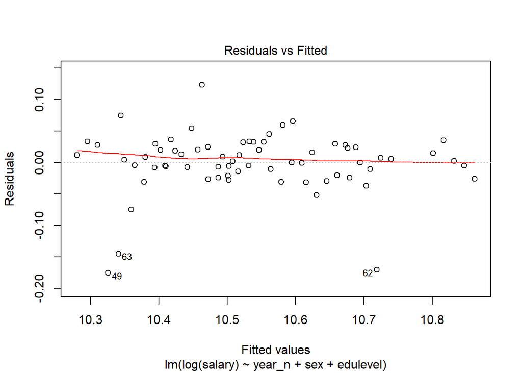

Residuals vs Fitted of model fit

```r
plot(model, which = 1)
```

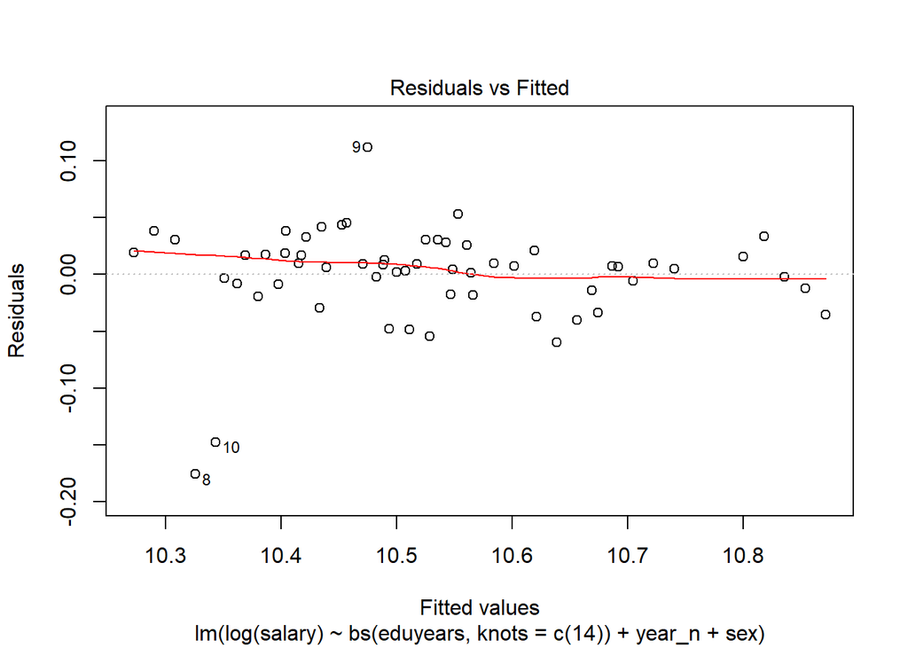

Residuals vs Fitted of model fit

```r
plot(modelcont, which = 1)
```

The Normal Q-Q shows some possible outliers.

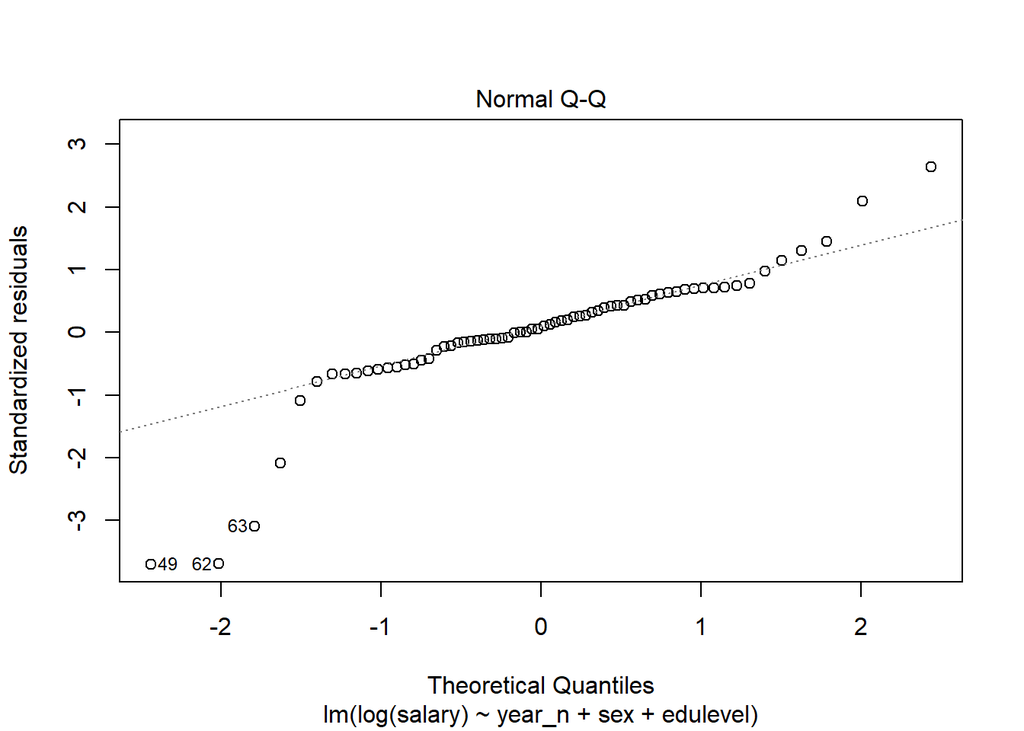

Normal Q-Q

```r
plot(model, which = 2)
```

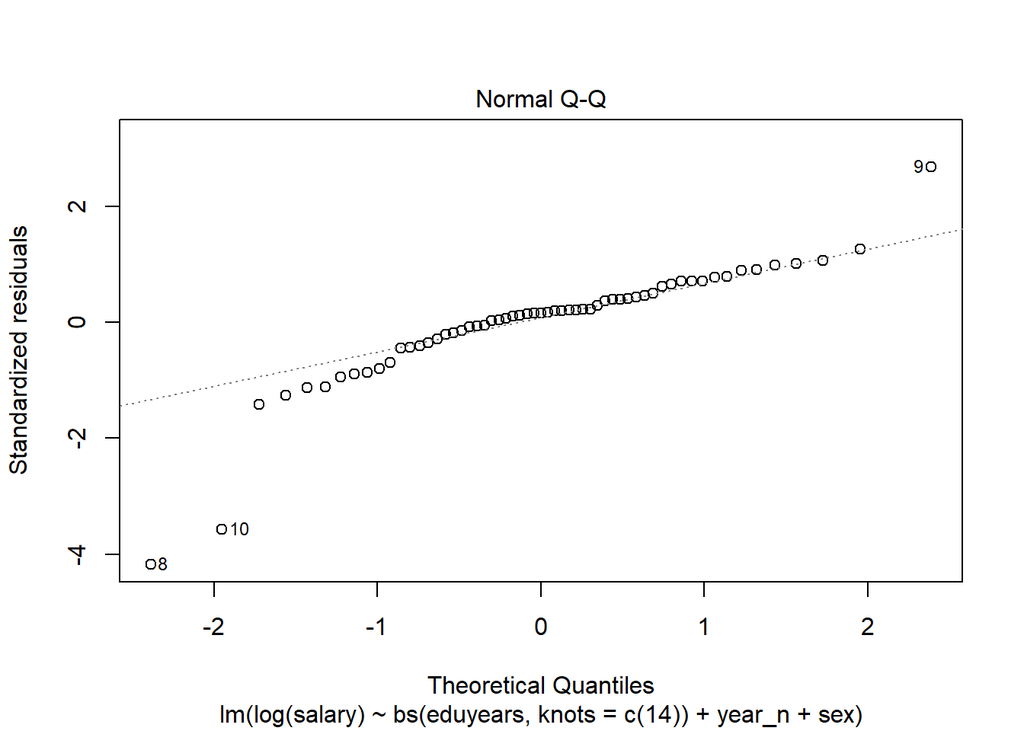

Normal Q-Q

```r
plot(modelcont, which = 2)
```

Again, the Standardised residuals show some possible outliers.

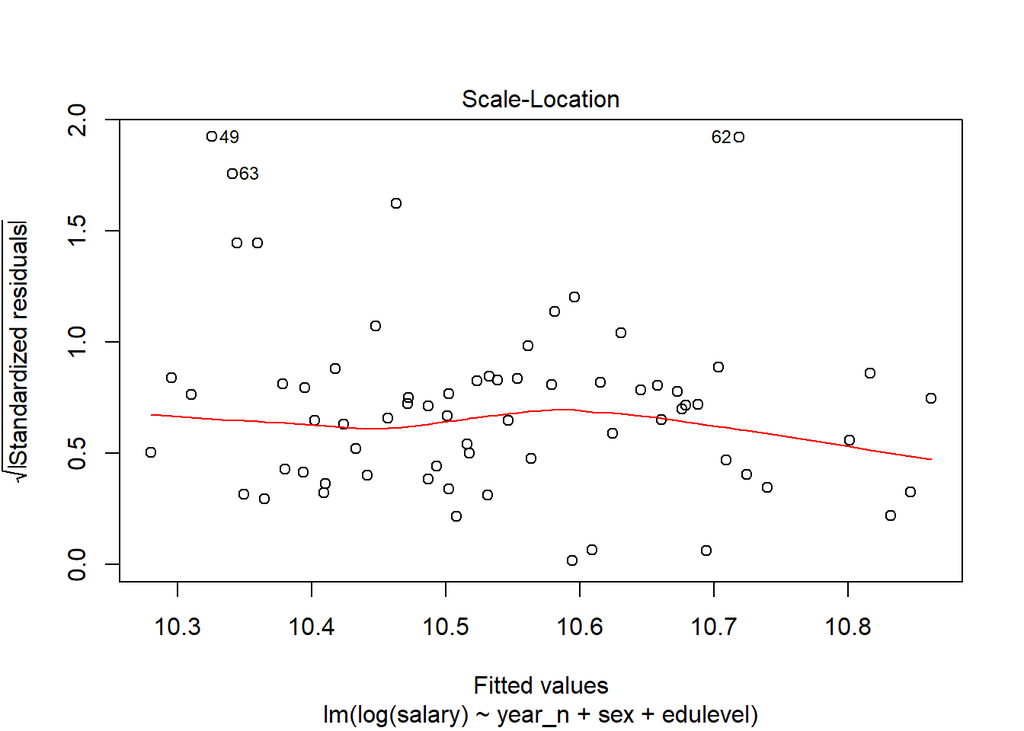

Scale-Location

```r
plot(model, which = 3)
```

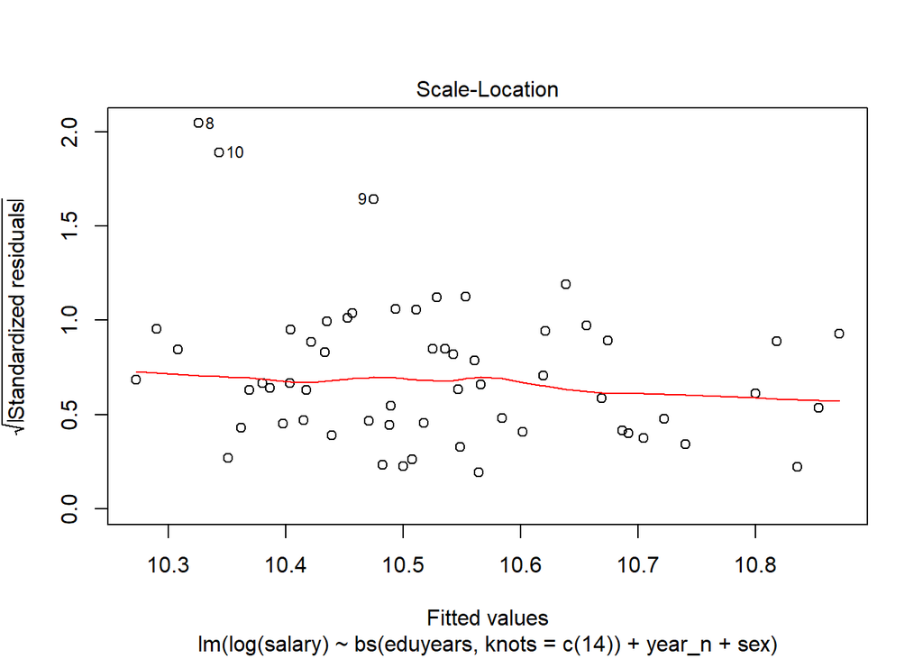

Scale-Location

```r
plot(modelcont, which = 3)
```

The outliers are also found in the Leverage plot.

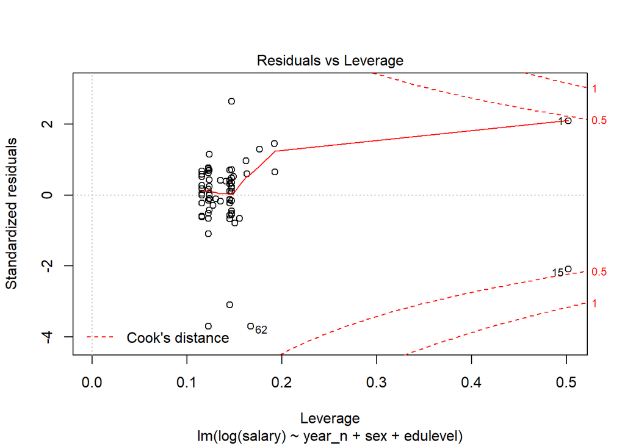

Residuals vs Leverage

```r
plot(model, which = 5)
```

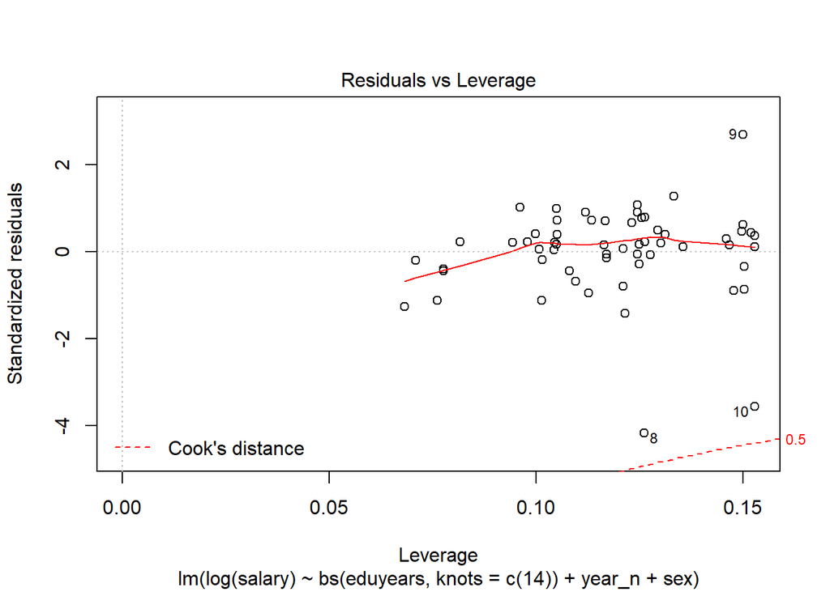

Residuals vs Leverage

```r
plot(modelcont, which = 5)
```